# Practical Machine Learning on Human Activity Recognition

TLTC

June 18, 2017

# Executive Summary

This paper uses practical machine learning techniques on Human Activity Recognition (HAR) problems. In particular, the dataset includes measurements on six participants - they were asked to perform one set of 10 repetitions of the Unilateral Dumbbell Biceps Curl in five different fashions: exactly according to the specification (five different classes from A to E). The goal is to build a model that accruately predict the class of activitiy given a set of measuresments.

# Data Preparation and Exploratory Analysis

## Getting Data

For best practice in reproducible research, datasets are sourced directly from the URLs instead of being downloaded manually first.

```r
URL1<-"https://d396qusza40orc.cloudfront.net/predmachlearn/pml-training.csv"
URL2<-"https://d396qusza40orc.cloudfront.net/predmachlearn/pml-testing.csv"
library(RCurl)
d1<-getURL(URL1)
train<-read.csv(textConnection(d1))
d2<-getURL(URL2)
test<-read.csv(textConnection(d2))
```

## Cross-Validation

Setting seed here for reproducible research and partitioning training and testing sets.

```r
library(caret)
set.seed(11111)
inTrain<-createDataPartition(train$classe, p=0.7, list=FALSE)
trainSet<-train[inTrain, ]
testSet<-train[-inTrain, ]
```

## Cleaning Data

```r
dim(trainSet)
```

```
## [1] 13737   160
```

First, cutting down the number of variables by removing zero covariates.

```r
nzv<-nearZeroVar(trainSet)
trainSet<-trainSet[,-nzv]
testSet<-testSet[,-nzv]
dim(trainSet)
```

```
## [1] 13737   109
```

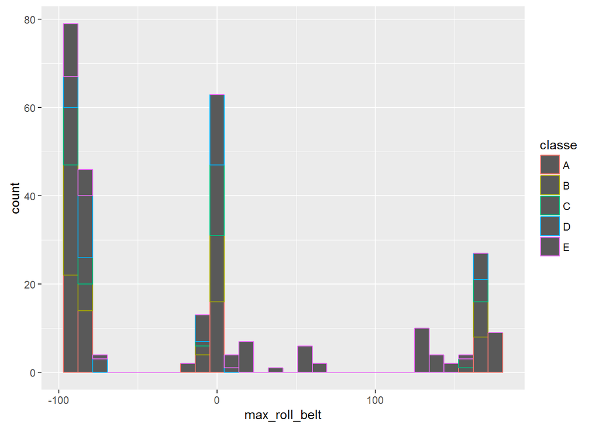

Doesn’t look like it gives much information on differentiating the activity class. Therefore, removing such variables.

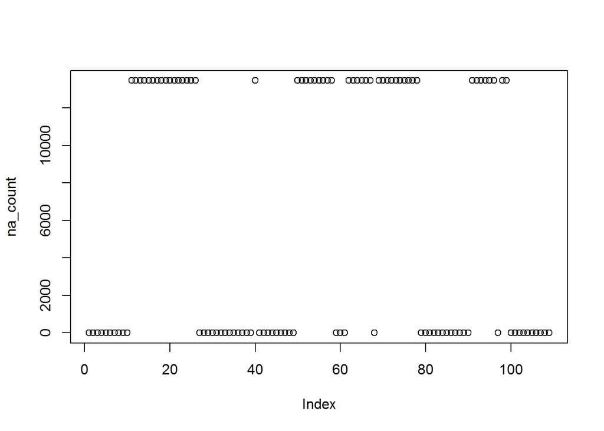

```r
na_count<-sapply(trainSet, function(y) sum(length(which(is.na(y)))))
plot(na_count)
```

Looks like the the threshold is 12,000.

```r
naDrop<-names(which(na_count>12000))
trainSet<-trainSet[,!names(trainSet) %in% naDrop]
testSet<-testSet[,!names(testSet) %in% naDrop]
```

Finally, take out descriptive variables that are not relevant for the anlysis.

```r
trainSet<-trainSet[,-c(1:5)]
testSet<-testSet[,-c(1:5)]
```

# Prediction Modeling

Given the high number of variables available in the dataset, a Random Forests approach seems better than the simple Decision Tree model. Thus a Random Forests model will be fitted and checked for accuracy. If the result is unsatisfactory, a more elaborate approach such as boosting or stacking will be considered.

## Random Forests

```r
library(randomForest)
numRF<- trainControl(method="cv", number=3, verboseIter=FALSE)
modFitRF<-train(classe~.,data=trainSet,method="rf",trControl=numRF)
predRF<-predict(modFitRF,testSet)
```

```r
confusionMxRF<-confusionMatrix(predRF,testSet$classe)
confusionMxRF$overall[1]
```

```
##  Accuracy
## 0.9981308
```

# Testing Prediction

Appy the model to the test dataset:

```r
predTest<-predict(modFitRF,test)
predTest
```

```
##  [1] B A B A A E D B A A B C B A E E A B B B
## Levels: A B C D E
```